# Homework 06

Ayanna Chatman

2023-10-21

```r
library(tidyverse)
library(moderndive)
library(ggthemes)
library(patchwork)
theme_set(theme_light())
```

```r
gen_employment <- read_csv("https://raw.githubusercontent.com/vaiseys/dav-course/main/Data/gender_employment.csv")
```

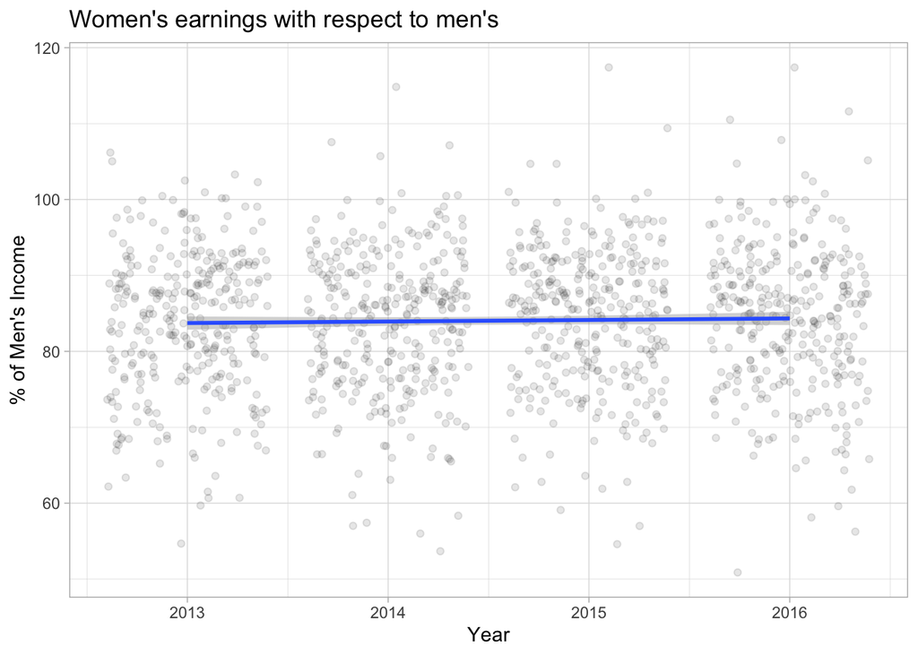

```r
gen_employment%>%
  ggplot(aes(x = year, y = wage_percent_of_male)) +
  geom_jitter(alpha = 0.1) +
  geom_smooth(method = "lm") +
  labs(title = "Women's earnings with respect to men's",
       y = "% of Men's Income",
       x = "Year")
```

## Question #1

```r
gen_employment <- gen_employment %>%
  mutate(major_category = as.factor(major_category),
         major_category = relevel(major_category, ref = "Management, Business, and Financial"))
```

```r
parallel_model <- lm(wage_percent_of_male ~ year + major_category,
                     data = gen_employment)

get_regression_table(parallel_model)
```

```
## # A tibble: 9 × 7
##   term                    estimate std_error statistic p_value lower_ci upper_ci
##   <chr>                      <dbl>     <dbl>     <dbl>   <dbl>    <dbl>    <dbl>
## 1 intercept               -307.      459.       -0.669   0.504 -1.21e+3  593.
## 2 year                       0.192     0.228     0.844   0.399 -2.54e-1    0.639
## 3 major_category: Comput…    6.32      0.946     6.68    0      4.46e+0    8.18
## 4 major_category: Educat…    5.76      0.985     5.84    0      3.82e+0    7.69
## 5 major_category: Health…    5.52      1.10      5.00    0      3.36e+0    7.68
## 6 major_category: Natura…    4.92      1.24      3.95    0      2.48e+0    7.35
## 7 major_category: Produc…   -1.31      0.96     -1.36    0.172 -3.20e+0    0.573
## 8 major_category: Sales …    3.33      0.858     3.88    0      1.64e+0    5.01
## 9 major_category: Service    6.08      0.885     6.87    0      4.34e+0    7.81
```

```r
get_regression_summaries(parallel_model)
```

```
## # A tibble: 1 × 9
##   r_squared adj_r_squared   mse  rmse sigma statistic p_value    df  nobs
##       <dbl>         <dbl> <dbl> <dbl> <dbl>     <dbl>   <dbl> <dbl> <dbl>
## 1     0.091         0.085  80.0  8.94  8.97      15.3       0     8  1242
```

```r
library(broom)
tidy(parallel_model)
```

```
## # A tibble: 9 × 5
##   term                                     estimate std.error statistic  p.value
##   <chr>                                       <dbl>     <dbl>     <dbl>    <dbl>
## 1 (Intercept)                              -307.      459.       -0.669 5.04e- 1
## 2 year                                        0.192     0.228     0.844 3.99e- 1
## 3 major_categoryComputer, Engineering, an…    6.32      0.946     6.68  3.56e-11
## 4 major_categoryEducation, Legal, Communi…    5.76      0.985     5.84  6.53e- 9
## 5 major_categoryHealthcare Practitioners …    5.52      1.10      5.00  6.41e- 7
## 6 major_categoryNatural Resources, Constr…    4.91      1.24      3.95  8.15e- 5
## 7 major_categoryProduction, Transportatio…   -1.31      0.960    -1.37  1.72e- 1
## 8 major_categorySales and Office              3.33      0.858     3.88  1.11e- 4
## 9 major_categoryService                       6.08      0.885     6.87  1.03e-11
```

**Using the coefficients from your model, calculate the wage percentage of male income for Sales and Office occupations in 2015.**

y = mx+b(coiefficient)

Si = -307 + 0.192(2015) + 3.33(1) = 83.21

Wage percentage of male income for Sales and Office Occ. in 2015 is 83.21%

**Now calculate the wage percentage of male income for Service occupations on 2016.**

Si = -307 + 0.192(2016) + 6.08(1) = 86.15

Wage percentage of male income for Service occupations in 2016 is 86.15%

## Question 2

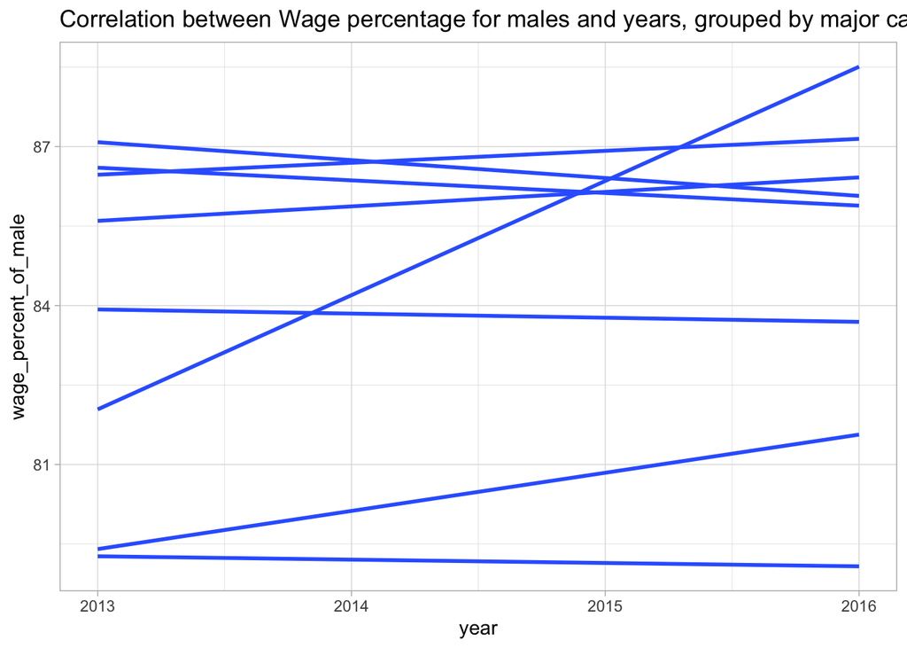

```r
ggplot(gen_employment,
       aes(x = year,
           y = wage_percent_of_male,
           group = major_category)) +
  labs(title = "Correlation between Wage percentage for males and years, grouped by major category") +
  geom_smooth(method = "lm",
              se = FALSE)
```

Despite what the model above assumes, the parallel trends assumption isn’t warranted, since there are intercepting lines.

## Question 3

```r
majyear_model <- lm(wage_percent_of_male ~ year*major_category,
                     data = gen_employment)
library(broom)
tidy(majyear_model)
```

```
## # A tibble: 16 × 5
##    term                                     estimate std.error statistic p.value
##    <chr>                                       <dbl>     <dbl>     <dbl>   <dbl>
##  1 (Intercept)                              -1.37e+3  1106.       -1.24    0.216
##  2 year                                      7.20e-1     0.549     1.31    0.190
##  3 major_categoryComputer, Engineering, an…  1.00e+3  1703.        0.589   0.556
##  4 major_categoryEducation, Legal, Communi…  1.94e+3  1774.        1.09    0.275
##  5 major_categoryHealthcare Practitioners …  9.06e+2  1987.        0.456   0.649
##  6 major_categoryNatural Resources, Constr… -2.89e+3  2232.       -1.29    0.196
##  7 major_categoryProduction, Transportatio…  1.58e+3  1735.        0.909   0.363
##  8 major_categorySales and Office            1.61e+3  1541.        1.05    0.296
##  9 major_categoryService                     2.14e+3  1595.        1.34    0.180
## 10 year:major_categoryComputer, Engineerin… -4.95e-1     0.845    -0.585   0.559
## 11 year:major_categoryEducation, Legal, Co… -9.59e-1     0.880    -1.09    0.276
## 12 year:major_categoryHealthcare Practitio… -4.47e-1     0.986    -0.453   0.651
## 13 year:major_categoryNatural Resources, C…  1.44e+0     1.11      1.30    0.195
## 14 year:major_categoryProduction, Transpor… -7.84e-1     0.861    -0.910   0.363
## 15 year:major_categorySales and Office      -7.98e-1     0.765    -1.04    0.297
## 16 year:major_categoryService               -1.06e+0     0.792    -1.34    0.182
```

[output not shown]

## Question 4

**Given that we have the ability to add interactions to models - i.e. to have slopes vary across categories -, why would we choose to build a model that assumes parallel trends?**

We would want to build a model that assumes parralel trends as the relationship between major categories, year, and wage percentage of males calls for a more complex model.

## Question 5

```r
simple_fit <- lm(wage_percent_of_male ~ year,
                 data = gen_employment)
tidy(simple_fit)
```

```
## # A tibble: 2 × 5
##   term        estimate std.error statistic p.value
##   <chr>          <dbl>     <dbl>     <dbl>   <dbl>
## 1 (Intercept) -322.      479.       -0.671   0.502
## 2 year           0.201     0.238     0.847   0.397
```

The y intercept of this mosel is -321.83 and the slope is 0.20.

```r
gen_employment %>%
  select(year, wage_percent_of_male, percent_female) %>%
  cor(use = "complete.obs")
```

```
##                             year wage_percent_of_male percent_female
## year                 1.000000000           0.02403895    0.004998286
## wage_percent_of_male 0.024038950           1.00000000    0.111464461
## percent_female       0.004998286           0.11146446    1.000000000
```

Wage percentage of male has a positive linear relationship to both year and percentage of females in the workspace, but it is quite small. Percentage of females in the workforce also has a positive linear relationship with year and wage percentage of males, but also quite small.

```r
multiple_fit <- lm(percent_female ~ wage_percent_of_male + year,
                   data = gen_employment)
tidy(multiple_fit)
```

```
## # A tibble: 3 × 5
##   term                 estimate std.error statistic   p.value
##   <chr>                   <dbl>     <dbl>     <dbl>     <dbl>
## 1 (Intercept)          -81.2    1248.       -0.0651 0.948
## 2 wage_percent_of_male   0.292     0.0739    3.94   0.0000843
## 3 year                   0.0509    0.620     0.0822 0.935
```

## Question 6

R-squared is the part of the dependent variable that can be determined by the independent variable, hence its name “the coefficient of determination”.

```r
simple_glanced <- glance(simple_fit)
simple_glanced$r.squared
```

```
## [1] 0.0005778711
```

```r
multiple_glanced <- glance(multiple_fit)
multiple_glanced$r.squared
```

```
## [1] 0.01242971
```

The r-squared for the simple_fit is 0.00058 and the r-squared for the multiple fit is 0.01243, which means that observed outcomes are replicated better/more accuratelt by the multiple fit model than the simple fit model.

Warning sign:

```r
random_numbers <- rnorm(n = nrow(gen_employment),
                        mean = 0,
                        sd = 4)
```

```r
gen_employment$random_noise <- random_numbers

# New model
random_fit <- lm(wage_percent_of_male ~ year + percent_female + random_noise, data = gen_employment)
```

```r
random_glanced <- glance(random_fit)
random_glanced$r.squared
```

```
## [1] 0.01316706
```

Based on this r-squared, the random-fit model that the observed outcomes are replicated better than both the multiple fit and simple fit models.